# NOMAS POR CURA

J. Eduardo Jaramillo

2018-07-02

En la entrega de este blog vamos a utilizar utilizar la tabla de billonarios de BLOOMBERG https://www.bloomberg.com/billionaires/ para realizar un ejercicio de análisis nomás por cura.

Esta es una imagen donde se muestra la tabla original.

[figure not shown]

tabla

El índice de billonarios de bloomberg nos ofrece datos sobre las personas más adineradas del mundo. En total se contabilizan 500 personas pero, por ejemplo, si quisieramos saber cuantos son por país, cuantos son por industria u otro dato pues los tenemos que contar uno por uno. Al ser sólo una tabla (-.-) <– *carita de weva* no nos ofrece nada divertido para visualizar. Nomás por cura nosotros vamos a hacer un breve análisis de la tabla. Lo primero que queremos saber es cuál es el país con más billonarios del mundo *SPOILER ALERT!!!* es **ESTADOS UNIDOS**.

Comenzamos primero por subir los paquetes de funciones que nos van a ayudar en ésta ardua y dura tarea de copiar y pegar información de internet.

```r
library(easypackages)
my_packages <- c("rvest", "tidyverse", "rgeos", "sf", "ggmap", "mapview", "readr", "knitr", "ggrepel", "kableExtra")
libraries(my_packages)
```

Para conseguir los datos, podríamos hacer un simple copy-paste de tooooooda la tabla y luego pegarla en excel pero la neta **QUE WEVA** además, cada vez que necesitemos traer los datos tenemos que hacer la misma operación (copiar y pegar los 500 registros a mano) osea **MAS QUE WEVA**.Por esto, haremos uso de la magia de las computadoras, el conocimiento milenario de los programadores que crearon el paquete de funciones **rvest**, y mucho internet para traer la tabla.

Lo chido de esto es que la computadora se comunica con la página web cada vez que se hace la operación entonces, uno sólo tiene que picar el botoncito para que se baje la info solita.

Comenzamos el archi-reconocido **copy-paste** indicando el *url* de donde jalaremos la información luego, guardamos en un vector de caracteres la info de la columna. Y **TATAAAAAAAAAAAN** listo.

```r
url <- "https://www.bloomberg.com/billionaires/"

position <- read_html(url) %>% #Aquí le dices a la compu de donde jalar la info
  html_nodes(".t-rank") %>% #Aquí le dices a la compu que columna jalar
  html_text() #Adivina que hace esto(La pone todo como texto y le quita un montón de carácteres que no sirven)

position <- position[(-1)]

nombre <- read_html(url) %>% #Lo mismo para otra columna
  html_nodes(".t-name") %>% #Lo mismo para otra columna
  html_text() #Lo mismo para otra columna

nombre <- nombre[(-1)]

net_worth <- read_html(url) %>% #Lo mismo para otra columna (todo pa abajo lo mismo)
  html_nodes(".t-nw") %>%
  html_text()

net_worth <- net_worth[(-1)]

last_change <- read_html(url) %>%
  html_nodes(".t-lcd") %>%
  html_text()


last_change <- last_change[(-1)]


YTD_change <- read_html(url) %>%
  html_nodes(".t-ycd") %>%
  html_text()

YTD_change <- YTD_change[(-1)]


SOVEREIGNT <- read_html(url) %>%
  html_nodes(".t-country") %>%
  html_text()

SOVEREIGNT <- SOVEREIGNT[(-1)]

industry <- read_html(url) %>%
  html_nodes(".t-industry") %>%
  html_text()

industry <- industry[(-1)]
```

Ya que tenemos listos nuestros ingredientes muchachitos…….vamos a juntarlos todos por que así separados no rifan. Como las columnas que tienen numeritos vienen con carateres especiales de moneda, suma y otros tenemos que quitarlos. Esto por que si quieres sumar dos celdas con un carácter especial la compu no lo reconoce como número y pues…….. te tira error.

Ah! también le cambio el nombre a Estados Unidos y Rusia, por que así me los enseñaron en la primaria………

```r
df <- tibble::tibble(position, nombre, SOVEREIGNT, net_worth, last_change, YTD_change) %>%
  mutate(net_worth = as.numeric(str_extract(net_worth, pattern = "(\\d+\\.?\\d+)")),
         last_change = as.numeric(str_extract(last_change, pattern = "(\\d+\\.?\\d?+)")),
         YTD_change = as.numeric(str_extract(YTD_change, pattern = "(\\d+\\.?\\d?+)")),
         SOVEREIGNT = fct_recode(SOVEREIGNT,
                                 "United States of America" = "United States",
                                 "Russia" = "Russian Federation"))

countries_locations <- read_csv("countries_locations.csv")
```

Ya teniendo nuestros ingredientes en la cazuela, los vamos a poner en la lumbre y le comenzamos a mover pa’ que salga el olor y nos de hambre. Osea.

Vamos a trabajar con los datos para poderlos presentar.

```r
countr_dat <- df %>%
  filter(!SOVEREIGNT %in% c("Gerorgia")) %>%
  group_by(SOVEREIGNT) %>%
  summarise(`NUMBER OF BILLIONAIRES` = n(),
            `SUM OF NET WORTH BY COUNTRY` = sum(net_worth)) %>%
  left_join(countries_locations, by = c("SOVEREIGNT" = "Country")) %>%
  mutate(LATITUDE = lat,
         LONGITUDE = lon) %>%
  filter(!is.na(lat)) %>%
  st_as_sf(coords = c("lon", "lat"), crs = 4326) %>%
  select(-`X1`) %>%
  filter(!SOVEREIGNT %in% c("Georgia")) %>%
  rename(., "COUNTRY" = "SOVEREIGNT")
```

Ora vamos a hacer un mapita interactivo *(acabo de aprender no me juzguen)* en el mapita van a salir puntitos y luego, si le picas al puntito va a salir informacioncita bonita, no tan interesante pero, *el mapa se mueve!!!!!!!!!!*

La información que sale son:.

1. Número de billonarios
2. Suma de todo el dinero que juntan los billonarios de cada país en dólares

Latitud, longitud y una columna que pueden igorar….

```r
mapview(countr_dat, zcol = "COUNTRY")
```

[interactive chart not shown]

Si ya se que sale una tablota estamos trabajando en eso may frends.

Bueno ya que tenemos un mapita bonito vamos a poner una tablita. En total son 47 países que figuran en la lista de los billonarios entonces vamos a hacer una tablita para ordernarlos de mayor a menor y ver que pedo con la vida.

En la tabla la columna **NO BILLONARIOS** quiere decir número de billonarios luego dicen que uno la acaga….

```r
df %>%
  select(SOVEREIGNT) %>%
  group_by(SOVEREIGNT) %>%
  summarise(`NO BILLONARIOS` = n()) %>%
  arrange(desc(`NO BILLONARIOS`)) %>%
  kable() %>%
  kable_styling(bootstrap_options = "striped", full_width = F, position = "left")
```

| SOVEREIGNT | NO BILLONARIOS |
| --- | --- |
| United States of America | 170 |
| China | 42 |
| Germany | 39 |
| Russia | 24 |
| India | 22 |
| Hong Kong | 20 |
| Brazil | 15 |
| Canada | 13 |
| United Kingdom | 13 |
| France | 11 |
| Sweden | 10 |
| Japan | 9 |
| Switzerland | 9 |
| Australia | 8 |
| Italy | 7 |
| Denmark | 6 |
| Indonesia | 6 |
| Korea, Republic of | 6 |
| Singapore | 6 |
| Malaysia | 5 |
| Mexico | 5 |
| Taiwan | 5 |
| Norway | 4 |
| Saudi Arabia | 4 |
| Thailand | 4 |
| Colombia | 3 |
| Israel | 3 |
| South Africa | 3 |
| Austria | 2 |
| Czech Republic | 2 |
| Egypt | 2 |
| Netherlands | 2 |
| Nigeria | 2 |
| Philippines | 2 |
| Spain | 2 |
| United Arab Emirates | 2 |
| Belgium | 1 |
| Cayman Islands | 1 |
| Chile | 1 |
| Cyprus | 1 |
| Finland | 1 |
| Georgia | 1 |
| Ireland | 1 |
| Liechtenstein | 1 |
| Monaco | 1 |
| New Zealand | 1 |
| Ukraine | 1 |

Ahora podemos ver que *Estados Unidos*, *China*, *Alemania*, *Rusia* e *India* son los cinco primeros lugares.

Igual las tablas dan weva, entonces por qué no ponemos la información en un mapa. Por cierto México está entre Taiwan y Malasia.

Para poner la información en un mapita chido tenemos que *bajar un mapita chido* unirlo con nuestros datos y luego *si dios quiere* como diría mi abuela mostramos la información.

```r
library(ggmap)

worldmap <- rnaturalearth::ne_download(scale = 110,
type = "countries",
category = "cultural",
destdir = tempdir(),
load = TRUE,
returnclass = "sf")
```

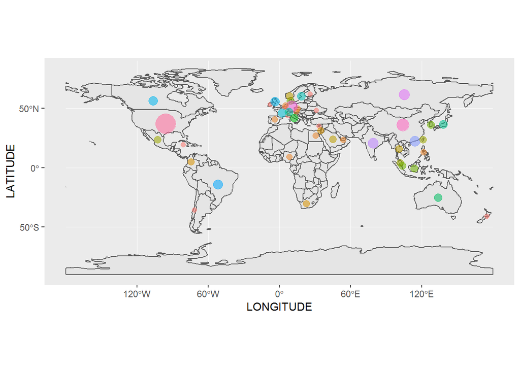

```r
ggplot(worldmap) +
  geom_sf() +
  geom_point(data = countr_dat, aes(x = LONGITUDE, y = LATITUDE,  size = `NUMBER OF BILLIONAIRES`, colour = as.factor(`NUMBER OF BILLIONAIRES`), alpha = .5), inherit.aes = FALSE) +
  scale_size_continuous(range = c(2,9)) +
  theme(legend.position = "none")
```

En este mapa mostramos de igual manera el número de billonarios por país. Las bolitas de colores representan la ubicación geográfica de los billonarios y el tamaño de la bolita representa la cantidad de billonarios por país. Por ahorita le vamos a dejar ahí. Si quieren más información, la pueden consultar en el link. https://www.bloomberg.com/billionaires/